# Create a multilayer pypenepma simulation

John Minter

Started 2018-09-19, Last modified: 2018-09-20

Abstract

The objective was to configure a pypenepma simulation of a thin film on a substrate without the default `vacuum` layer. This example configures a 200 nm C layer on a Fe substrate. This was part of an analysis to determine the effect of substrate density value (not clear how it is handled) on the intensity of transitions from a light element (C) on a heavier element (Fe). I like the way pypenelope stores the simulation parameters in a human/computer readable XML file and generates the materials and `penepma.in` file for the simulation on the file. it is a good way to share reproducible simulations.

I had found it difficult to remove the default `Vacuum` material entry. It took me a while to figure out how to do this.

# 1 Introduction

# 2 Procedure

## 2.1 Define the new simulation

When we start a new simulation we are greeted by a Welcome Screen. Enter a name for the simulation and choose a folder for the results using the GUI as shown below. Then press the `Next` button.

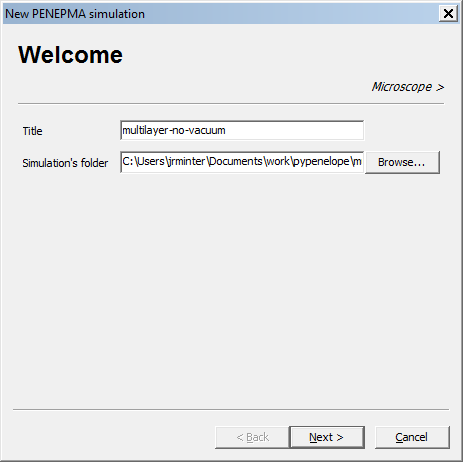

## 2.2 Set the microscope voltage

Set the appropriate microscope voltage and take-off angle. Then press the `Next` button.

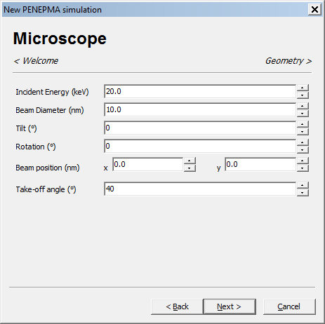

## 2.3 Choose the multilayer geometry

The Default simulation is a `Substrate`. Use the pull-down window to select `Multilayer(s)` which is the last choice in the menu. You will see a Window that looks like this. Press the `+` box to add a material .

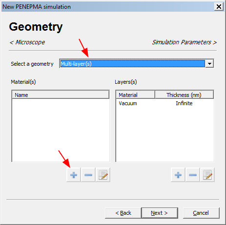

## 2.4 Start definition of the substrate material

When you first see the dialog the values will be empty and the top box will be checked and the bottom box will not be checked.

1. Uncheck the top box and enter the name of the material, in this example `Fe`.
2. Check the bottom box to select a user-supplied density. In this example I wanted to test how the density setting changed the output and used a high density of 10.

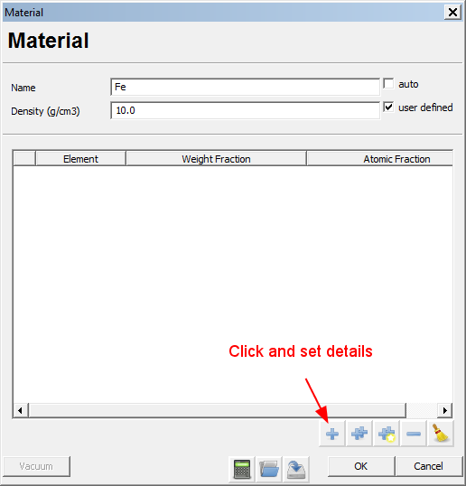

The `+` button gives you a nice periodic table to make a selection

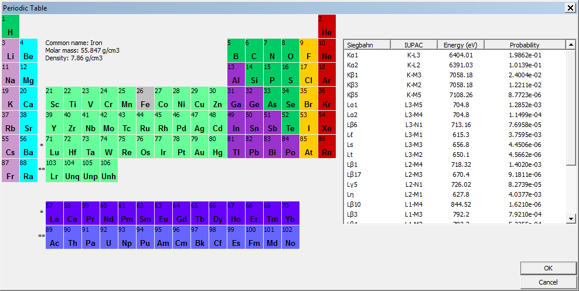

When you are done press `OK` and finish adding the input

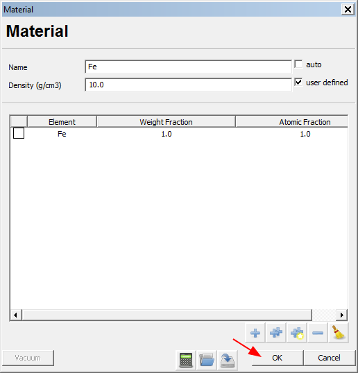

When you are done press `OK`

Now we want to set the substrate to `Fe`.

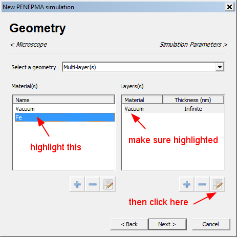

You will get an `Edit layer` box that looks like this

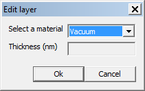

after setting the substrate to Fe it should look like this

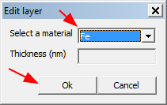

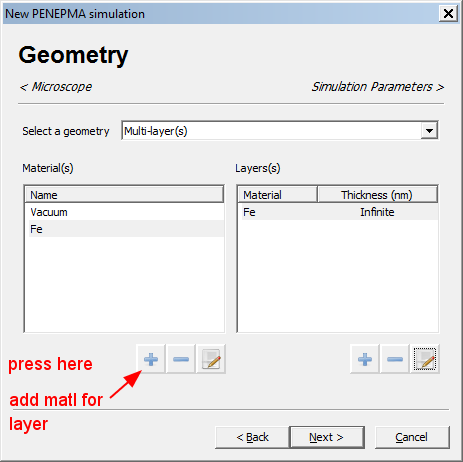

Then press `+` and add a material for the thin film. Choose C with a density of 2.26 g/cm3

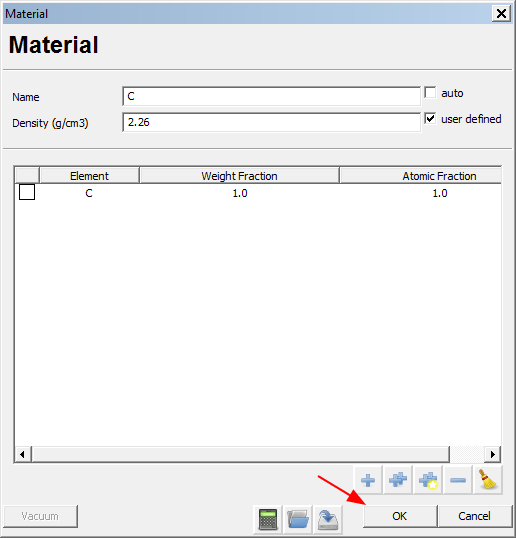

## 2.5 Add the C layer

The window should look like this

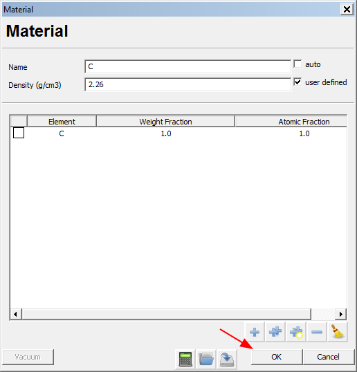

Now:

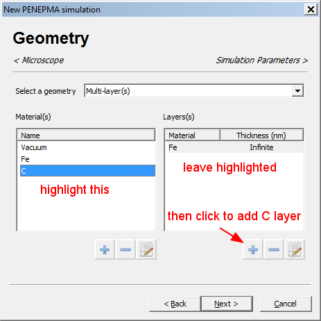

Note how you get the default layer window with `Vacuum` highlighted and a thickness of 10 nm.

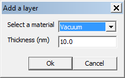

Use the pull-down window to select `C` and set the thickness to `200.0` nm.

The window should look like this

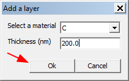

Then you can press `OK` and will get

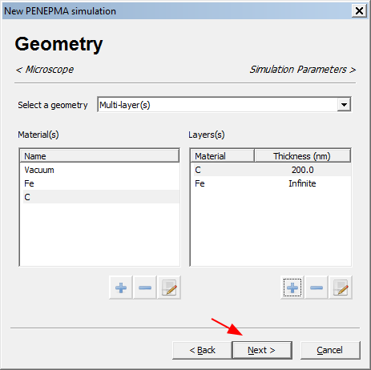

We now have the geometry configured so we can go to the next menu.

## 2.6 set the simulation parameters

We now get the base parameters menu

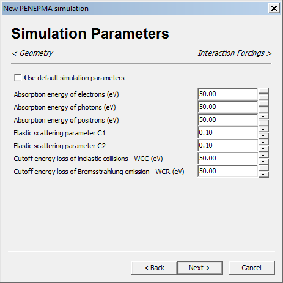

I usually click and un-click the default check-box and look at the papers by Llovett and Salvat to see if I should change them. Note how the values have changed from the defaults.

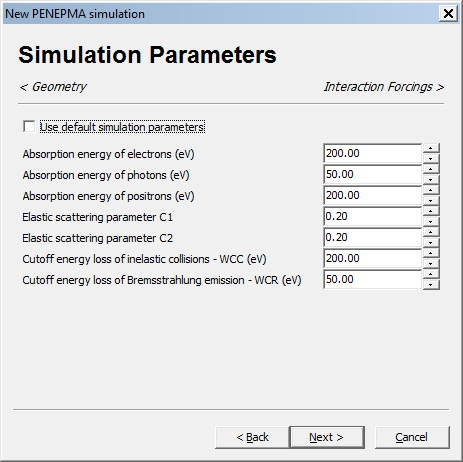

## 2.7 set the interaction forcing parameters

Press `Next` to go to the `Interaction Forcing` menu. I click the `default` button and start there.

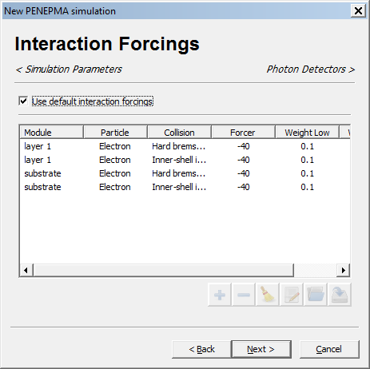

Press `Next` to set the photon detectors

## 2.8 Set the Photon Detectors

You can have many by default. I start with the default detectors

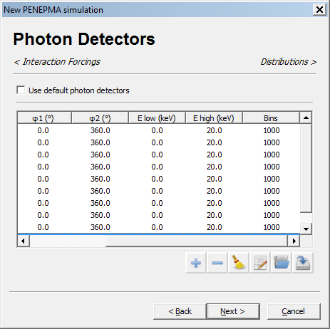

and delete all but the last

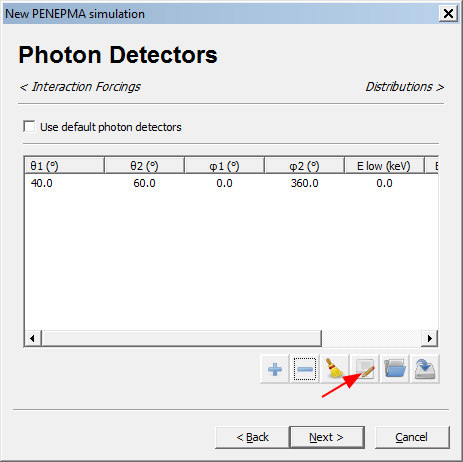

and then edit the parameters

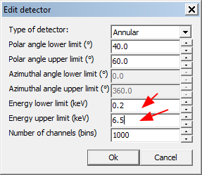

The most important parameter are the low and high energy values. We want to use out maximum of 1000 channels to cover our desired transitions.

When finished press next

## 2.9 Set the Distribution parameter

We start with this menu

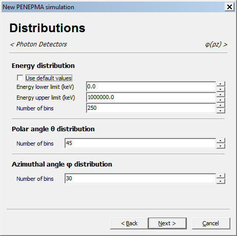

And edit to fit the system

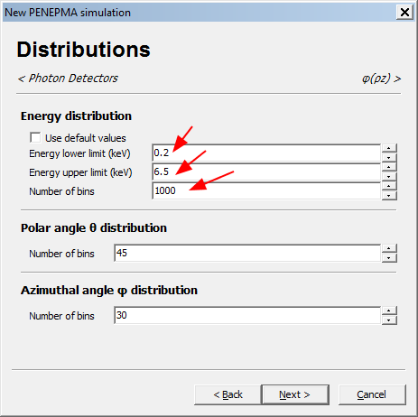

Now we can go to the phi-rho-z menu

## 2.10 Phi-Rho-Z

We start with the base menu and add transitions using the `+` button

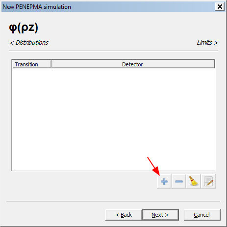

And add the C Ka

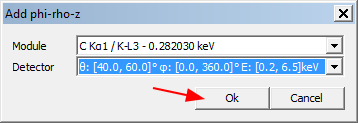

Repeat for the FeKa and Fe La and the final window looks like this

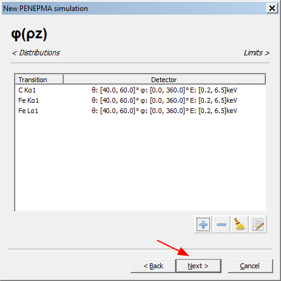

We can the move on with `Next`

## 2.11 Configure limits

Here we configure limits. One can use number of showers (trajectories), time (in sec), or uncertainty of the intensity of a transition.

The default I set here is `28800` sec (8 hrs).

I find it difficult to select a uncertainty value for a new system because the simulation time increases with the inverse square of the uncertainty. I found it hard to predict values that would not be cut-off by a reasonable time limit (8 to 40 hrs).

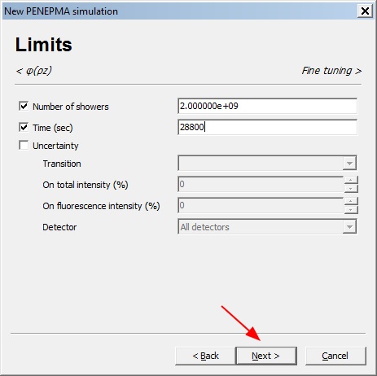

Then we press `Finish`. This writes the multilayer xml file which does not contain the `vacuum` dummy layer.